[figure not shown]

# Project: Investigate a Dataset - FBI Gun Data

# - Callie Lamb

## Table of Contents

- Introduction
- Data Wrangling
- Exploratory Data Analysis
- Conclusions
- References

## Introduction

Following the Brady Handgun Violence Prevention Act that was mandated in 1993, the FBI launched the National Instant Criminal Background Check System (NICS) on November 30, 1998. NICS is used by Federal Firearms Licensees (FFL) to determine whether a prospective buyer is eligible to buy firearms or explosives. Prior to making a sale, FFL's or other designated agencies use the NICS to ensure that each customer does not have a criminal record. The gun data that I will be exploring is provided by the NICS. I will also be exploring 2016 Census data that was retrieved from Census.gov.

Below I will be analyzing and exploring the data to answer these 3 questions:

Question 1: What 2016 Census data trends closely with 2016 FBI gun data?

Question 2: What type of gun has the most background checks performed?

Question 3: What US State performs the most background checks on the gun type answer from question 2?

## Data Wrangling

```python
# Importing relevant libraries
import pandas as pd
import numpy as np
import seaborn as sns
import matplotlib.pyplot as plt
%matplotlib inline

# Data locations
file_names = [r'C:\Users\cai318\Documents\DS\u.s.-census-data.csv',
              r'C:\Users\cai318\Documents\DS\gun-data.csv']

# Read data as DataFrames
census_df = pd.read_csv(file_names[0])
gun_df = pd.read_csv(file_names[1])

# Printing the census_df row range, column indexes, column names, Null/Non_Null count, and Dtype for each column.
census_df.info()
```

```
<class 'pandas.core.frame.DataFrame'>
RangeIndex: 85 entries, 0 to 84
Data columns (total 52 columns):
 #   Column          Non-Null Count  Dtype
---  ------          --------------  -----
 0   Fact            80 non-null     object
 1   Fact Note       28 non-null     object
 2   Alabama         65 non-null     object
 3   Alaska          65 non-null     object
 4   Arizona         65 non-null     object
 5   Arkansas        65 non-null     object
 6   California      65 non-null     object
 7   Colorado        65 non-null     object
 8   Connecticut     65 non-null     object
 9   Delaware        65 non-null     object
```

[output cut: 44 more lines]

The Dtype is object and will need to be converted to floats.

```python
# Checking the first 5 rows of data from census_df
census_df.head()
```

|  | Fact | Fact Note | Alabama | Alaska | Arizona | Arkansas | California | Colorado | Connecticut | Delaware | ... | South Dakota | Tennessee | Texas | Utah | Vermont | Virginia | Washington | West Virginia | Wisconsin | Wyoming |
| --- | --- | --- | --- | --- | --- | --- | --- | --- | --- | --- | --- | --- | --- | --- | --- | --- | --- | --- | --- | --- | --- |
| 0 | Population estimates, July 1, 2016, (V2016) | NaN | 4,863,300 | 741,894 | 6,931,071 | 2,988,248 | 39,250,017 | 5,540,545 | 3,576,452 | 952,065 | ... | 865454 | 6651194 | 27,862,596 | 3,051,217 | 624,594 | 8,411,808 | 7,288,000 | 1,831,102 | 5,778,708 | 585,501 |
| 1 | Population estimates base, April 1, 2010, (V2... | NaN | 4,780,131 | 710,249 | 6,392,301 | 2,916,025 | 37,254,522 | 5,029,324 | 3,574,114 | 897,936 | ... | 814195 | 6346298 | 25,146,100 | 2,763,888 | 625,741 | 8,001,041 | 6,724,545 | 1,853,011 | 5,687,289 | 563,767 |
| 2 | Population, percent change - April 1, 2010 (es... | NaN | 1.70% | 4.50% | 8.40% | 2.50% | 5.40% | 10.20% | 0.10% | 6.00% | ... | 0.063 | 0.048 | 10.80% | 10.40% | -0.20% | 5.10% | 8.40% | -1.20% | 1.60% | 3.90% |
| 3 | Population, Census, April 1, 2010 | NaN | 4,779,736 | 710,231 | 6,392,017 | 2,915,918 | 37,253,956 | 5,029,196 | 3,574,097 | 897,934 | ... | 814180 | 6346105 | 25,145,561 | 2,763,885 | 625,741 | 8,001,024 | 6,724,540 | 1,852,994 | 5,686,986 | 563,626 |
| 4 | Persons under 5 years, percent, July 1, 2016, ... | NaN | 6.00% | 7.30% | 6.30% | 6.40% | 6.30% | 6.10% | 5.20% | 5.80% | ... | 0.071 | 0.061 | 7.20% | 8.30% | 4.90% | 6.10% | 6.20% | 5.50% | 5.80% | 6.50% |

5 rows × 52 columns

There are non-numeric charactors in the data, I will need to remove these for analysis.

```python
# Checking rows 62 - 84 of census_df (including row 62 for visual comparison).
census_df.iloc[63:,:]
```

|  | Fact | Fact Note | Alabama | Alaska | Arizona | Arkansas | California | Colorado | Connecticut | Delaware | ... | South Dakota | Tennessee | Texas | Utah | Vermont | Virginia | Washington | West Virginia | Wisconsin | Wyoming |
| --- | --- | --- | --- | --- | --- | --- | --- | --- | --- | --- | --- | --- | --- | --- | --- | --- | --- | --- | --- | --- | --- |
| 63 | Land area in square miles, 2010 | NaN | 50,645.33 | 570,640.95 | 113,594.08 | 52,035.48 | 155,779.22 | 103,641.89 | 4,842.36 | 1,948.54 | ... | 75811 | 41234.9 | 261,231.71 | 82,169.62 | 9,216.66 | 39,490.09 | 66,455.52 | 24,038.21 | 54,157.80 | 97,093.14 |
| 64 | FIPS Code | NaN | "01" | "02" | "04" | "05" | "06" | "08" | "09" | "10" | ... | "46" | "47" | "48" | "49" | "50" | "51" | "53" | "54" | "55" | "56" |
| 65 | NaN | NaN | NaN | NaN | NaN | NaN | NaN | NaN | NaN | NaN | ... | NaN | NaN | NaN | NaN | NaN | NaN | NaN | NaN | NaN | NaN |
| 66 | NOTE: FIPS Code values are enclosed in quotes ... | NaN | NaN | NaN | NaN | NaN | NaN | NaN | NaN | NaN | ... | NaN | NaN | NaN | NaN | NaN | NaN | NaN | NaN | NaN | NaN |
| 67 | NaN | NaN | NaN | NaN | NaN | NaN | NaN | NaN | NaN | NaN | ... | NaN | NaN | NaN | NaN | NaN | NaN | NaN | NaN | NaN | NaN |
| 68 | Value Notes | NaN | NaN | NaN | NaN | NaN | NaN | NaN | NaN | NaN | ... | NaN | NaN | NaN | NaN | NaN | NaN | NaN | NaN | NaN | NaN |
| 69 | 1 | Includes data not distributed by county. | NaN | NaN | NaN | NaN | NaN | NaN | NaN | NaN | ... | NaN | NaN | NaN | NaN | NaN | NaN | NaN | NaN | NaN | NaN |
| 70 | NaN | NaN | NaN | NaN | NaN | NaN | NaN | NaN | NaN | NaN | ... | NaN | NaN | NaN | NaN | NaN | NaN | NaN | NaN | NaN | NaN |
| 71 | Fact Notes | NaN | NaN | NaN | NaN | NaN | NaN | NaN | NaN | NaN | ... | NaN | NaN | NaN | NaN | NaN | NaN | NaN | NaN | NaN | NaN |
| 72 | (a) | Includes persons reporting only one race | NaN | NaN | NaN | NaN | NaN | NaN | NaN | NaN | ... | NaN | NaN | NaN | NaN | NaN | NaN | NaN | NaN | NaN | NaN |
| 73 | (b) | Hispanics may be of any race, so also are incl... | NaN | NaN | NaN | NaN | NaN | NaN | NaN | NaN | ... | NaN | NaN | NaN | NaN | NaN | NaN | NaN | NaN | NaN | NaN |
| 74 | (c) | Economic Census - Puerto Rico data are not com... | NaN | NaN | NaN | NaN | NaN | NaN | NaN | NaN | ... | NaN | NaN | NaN | NaN | NaN | NaN | NaN | NaN | NaN | NaN |
| 75 | NaN | NaN | NaN | NaN | NaN | NaN | NaN | NaN | NaN | NaN | ... | NaN | NaN | NaN | NaN | NaN | NaN | NaN | NaN | NaN | NaN |
| 76 | Value Flags | NaN | NaN | NaN | NaN | NaN | NaN | NaN | NaN | NaN | ... | NaN | NaN | NaN | NaN | NaN | NaN | NaN | NaN | NaN | NaN |
| 77 | - | Either no or too few sample observations were ... | NaN | NaN | NaN | NaN | NaN | NaN | NaN | NaN | ... | NaN | NaN | NaN | NaN | NaN | NaN | NaN | NaN | NaN | NaN |
| 78 | D | Suppressed to avoid disclosure of confidential... | NaN | NaN | NaN | NaN | NaN | NaN | NaN | NaN | ... | NaN | NaN | NaN | NaN | NaN | NaN | NaN | NaN | NaN | NaN |
| 79 | F | Fewer than 25 firms | NaN | NaN | NaN | NaN | NaN | NaN | NaN | NaN | ... | NaN | NaN | NaN | NaN | NaN | NaN | NaN | NaN | NaN | NaN |
| 80 | FN | Footnote on this item in place of data | NaN | NaN | NaN | NaN | NaN | NaN | NaN | NaN | ... | NaN | NaN | NaN | NaN | NaN | NaN | NaN | NaN | NaN | NaN |
| 81 | NaN | Not available | NaN | NaN | NaN | NaN | NaN | NaN | NaN | NaN | ... | NaN | NaN | NaN | NaN | NaN | NaN | NaN | NaN | NaN | NaN |
| 82 | S | Suppressed; does not meet publication standards | NaN | NaN | NaN | NaN | NaN | NaN | NaN | NaN | ... | NaN | NaN | NaN | NaN | NaN | NaN | NaN | NaN | NaN | NaN |
| 83 | X | Not applicable | NaN | NaN | NaN | NaN | NaN | NaN | NaN | NaN | ... | NaN | NaN | NaN | NaN | NaN | NaN | NaN | NaN | NaN | NaN |
| 84 | Z | Value greater than zero but less than half uni... | NaN | NaN | NaN | NaN | NaN | NaN | NaN | NaN | ... | NaN | NaN | NaN | NaN | NaN | NaN | NaN | NaN | NaN | NaN |

22 rows × 52 columns

```python
# Dropping rows 63 - 84, and the "Fact Note" column from census_df.
census_df = census_df.iloc[:64,:].drop('Fact Note',axis = 1)
# Check
census_df.info()
```

```
<class 'pandas.core.frame.DataFrame'>
RangeIndex: 64 entries, 0 to 63
Data columns (total 51 columns):
 #   Column          Non-Null Count  Dtype
---  ------          --------------  -----
 0   Fact            64 non-null     object
 1   Alabama         64 non-null     object
 2   Alaska          64 non-null     object
 3   Arizona         64 non-null     object
 4   Arkansas        64 non-null     object
 5   California      64 non-null     object
 6   Colorado        64 non-null     object
 7   Connecticut     64 non-null     object
 8   Delaware        64 non-null     object
 9   Florida         64 non-null     object
```

[output cut: 43 more lines]

"Fact Note" column dropped

```python
# Removing known non-numeric characters from census_df column values
for i in census_df.columns[1:]:
    census_df[i] = census_df[i].str.replace("%","")
    census_df[i] = census_df[i].str.replace("$","")
    census_df[i] = census_df[i].str.replace(",","")
# Check
census_df.head()
```

|  | Fact | Alabama | Alaska | Arizona | Arkansas | California | Colorado | Connecticut | Delaware | Florida | ... | South Dakota | Tennessee | Texas | Utah | Vermont | Virginia | Washington | West Virginia | Wisconsin | Wyoming |
| --- | --- | --- | --- | --- | --- | --- | --- | --- | --- | --- | --- | --- | --- | --- | --- | --- | --- | --- | --- | --- | --- |
| 0 | Population estimates, July 1, 2016, (V2016) | 4863300 | 741894 | 6931071 | 2988248 | 39250017 | 5540545 | 3576452 | 952065 | 20612439 | ... | 865454 | 6651194 | 27862596 | 3051217 | 624594 | 8411808 | 7288000 | 1831102 | 5778708 | 585501 |
| 1 | Population estimates base, April 1, 2010, (V2... | 4780131 | 710249 | 6392301 | 2916025 | 37254522 | 5029324 | 3574114 | 897936 | 18804592 | ... | 814195 | 6346298 | 25146100 | 2763888 | 625741 | 8001041 | 6724545 | 1853011 | 5687289 | 563767 |
| 2 | Population, percent change - April 1, 2010 (es... | 1.70 | 4.50 | 8.40 | 2.50 | 5.40 | 10.20 | 0.10 | 6.00 | 9.60 | ... | 0.063 | 0.048 | 10.80 | 10.40 | -0.20 | 5.10 | 8.40 | -1.20 | 1.60 | 3.90 |
| 3 | Population, Census, April 1, 2010 | 4779736 | 710231 | 6392017 | 2915918 | 37253956 | 5029196 | 3574097 | 897934 | 18801310 | ... | 814180 | 6346105 | 25145561 | 2763885 | 625741 | 8001024 | 6724540 | 1852994 | 5686986 | 563626 |
| 4 | Persons under 5 years, percent, July 1, 2016, ... | 6.00 | 7.30 | 6.30 | 6.40 | 6.30 | 6.10 | 5.20 | 5.80 | 5.50 | ... | 0.071 | 0.061 | 7.20 | 8.30 | 4.90 | 6.10 | 6.20 | 5.50 | 5.80 | 6.50 |

5 rows × 51 columns

Non numeric charactors removed from data values

```python
# Convert dtype from object to float on columns 1 - end
for i in census_df.columns[1:]:
    census_df[i] = pd.to_numeric(census_df[i], errors = 'coerce')
# Check
census_df.info()
```

```
<class 'pandas.core.frame.DataFrame'>
RangeIndex: 64 entries, 0 to 63
Data columns (total 51 columns):
 #   Column          Non-Null Count  Dtype
---  ------          --------------  -----
 0   Fact            64 non-null     object
 1   Alabama         64 non-null     float64
 2   Alaska          63 non-null     float64
 3   Arizona         64 non-null     float64
 4   Arkansas        64 non-null     float64
 5   California      64 non-null     float64
 6   Colorado        64 non-null     float64
 7   Connecticut     64 non-null     float64
 8   Delaware        64 non-null     float64
 9   Florida         64 non-null     float64
```

[output cut: 43 more lines]

Dtype has changed from 'object' to 'float64' in the columns needed

By using 'coerce' error handeling, it turned a handful of values that were non-numeric (that I didn't catch like: 'D', 'F'...) into nulls.

```python
# Replacing nulls with 0.0
census_df.fillna(0, inplace = True, axis = 0)
# Check
census_df.info()
```

```
<class 'pandas.core.frame.DataFrame'>
RangeIndex: 64 entries, 0 to 63
Data columns (total 51 columns):
 #   Column          Non-Null Count  Dtype
---  ------          --------------  -----
 0   Fact            64 non-null     object
 1   Alabama         64 non-null     float64
 2   Alaska          64 non-null     float64
 3   Arizona         64 non-null     float64
 4   Arkansas        64 non-null     float64
 5   California      64 non-null     float64
 6   Colorado        64 non-null     float64
 7   Connecticut     64 non-null     float64
 8   Delaware        64 non-null     float64
 9   Florida         64 non-null     float64
```

[output cut: 43 more lines]

All items are now non-null

```python
# Checking for duplicates in census_df.
sum(census_df.duplicated())
```

```
0
```

```python
# GUN DATA CLEANING
# Printing the gun data row range, column indexes, column names, Null/Non_Null count, and Dtype for each column.
gun_df.info()
```

```
<class 'pandas.core.frame.DataFrame'>
RangeIndex: 12485 entries, 0 to 12484
Data columns (total 27 columns):
 #   Column                     Non-Null Count  Dtype
---  ------                     --------------  -----
 0   month                      12485 non-null  object
 1   state                      12485 non-null  object
 2   permit                     12461 non-null  float64
 3   permit_recheck             1100 non-null   float64
 4   handgun                    12465 non-null  float64
 5   long_gun                   12466 non-null  float64
 6   other                      5500 non-null   float64
 7   multiple                   12485 non-null  int64
 8   admin                      12462 non-null  float64
 9   prepawn_handgun            10542 non-null  float64
```

[output cut: 19 more lines]

There are 12485 rows of data, but most columns have missing entries

```python
# Checking the first 5 rows of data from gun_df.
gun_df.head()
```

|  | month | state | permit | permit_recheck | handgun | long_gun | other | multiple | admin | prepawn_handgun | ... | returned_other | rentals_handgun | rentals_long_gun | private_sale_handgun | private_sale_long_gun | private_sale_other | return_to_seller_handgun | return_to_seller_long_gun | return_to_seller_other | totals |
| --- | --- | --- | --- | --- | --- | --- | --- | --- | --- | --- | --- | --- | --- | --- | --- | --- | --- | --- | --- | --- | --- |
| 0 | 2017-09 | Alabama | 16717.0 | 0.0 | 5734.0 | 6320.0 | 221.0 | 317 | 0.0 | 15.0 | ... | 0.0 | 0.0 | 0.0 | 9.0 | 16.0 | 3.0 | 0.0 | 0.0 | 3.0 | 32019 |
| 1 | 2017-09 | Alaska | 209.0 | 2.0 | 2320.0 | 2930.0 | 219.0 | 160 | 0.0 | 5.0 | ... | 0.0 | 0.0 | 0.0 | 17.0 | 24.0 | 1.0 | 0.0 | 0.0 | 0.0 | 6303 |
| 2 | 2017-09 | Arizona | 5069.0 | 382.0 | 11063.0 | 7946.0 | 920.0 | 631 | 0.0 | 13.0 | ... | 0.0 | 0.0 | 0.0 | 38.0 | 12.0 | 2.0 | 0.0 | 0.0 | 0.0 | 28394 |
| 3 | 2017-09 | Arkansas | 2935.0 | 632.0 | 4347.0 | 6063.0 | 165.0 | 366 | 51.0 | 12.0 | ... | 0.0 | 0.0 | 0.0 | 13.0 | 23.0 | 0.0 | 0.0 | 2.0 | 1.0 | 17747 |
| 4 | 2017-09 | California | 57839.0 | 0.0 | 37165.0 | 24581.0 | 2984.0 | 0 | 0.0 | 0.0 | ... | 0.0 | 0.0 | 0.0 | 0.0 | 0.0 | 0.0 | 0.0 | 0.0 | 0.0 | 123506 |

5 rows × 27 columns

I need to seperate years/months from 'month' column into subcolumns that are int data types.

```python
# Gun_df - Creating subsets from  the 'Month' column. An integer subset for 'Month', another for 'Year'.
# Creating integer 'Month' subset.
gun_df['months'] = gun_df['month'].apply(lambda x: x.split("-")[1]).astype(int)
# Check
gun_df['months'].unique()
```

```
array([ 9,  8,  7,  6,  5,  4,  3,  2,  1, 12, 11, 10])
```

Months created

```python
# Creating 'Year' subset.
gun_df['year'] = gun_df['month'].apply(lambda x: x.split("-")[0]).astype(int)
# Check
gun_df['year'].unique()
```

```
array([2017, 2016, 2015, 2014, 2013, 2012, 2011, 2010, 2009, 2008, 2007,
       2006, 2005, 2004, 2003, 2002, 2001, 2000, 1999, 1998])
```

Years created

```python
# Droping the 'month' column as it is no longer needed.
gun_df.drop('month', inplace = True, axis = 1)
# Check
gun_df.head()
```

|  | state | permit | permit_recheck | handgun | long_gun | other | multiple | admin | prepawn_handgun | prepawn_long_gun | ... | rentals_long_gun | private_sale_handgun | private_sale_long_gun | private_sale_other | return_to_seller_handgun | return_to_seller_long_gun | return_to_seller_other | totals | months | year |
| --- | --- | --- | --- | --- | --- | --- | --- | --- | --- | --- | --- | --- | --- | --- | --- | --- | --- | --- | --- | --- | --- |
| 0 | Alabama | 16717.0 | 0.0 | 5734.0 | 6320.0 | 221.0 | 317 | 0.0 | 15.0 | 21.0 | ... | 0.0 | 9.0 | 16.0 | 3.0 | 0.0 | 0.0 | 3.0 | 32019 | 9 | 2017 |
| 1 | Alaska | 209.0 | 2.0 | 2320.0 | 2930.0 | 219.0 | 160 | 0.0 | 5.0 | 2.0 | ... | 0.0 | 17.0 | 24.0 | 1.0 | 0.0 | 0.0 | 0.0 | 6303 | 9 | 2017 |
| 2 | Arizona | 5069.0 | 382.0 | 11063.0 | 7946.0 | 920.0 | 631 | 0.0 | 13.0 | 6.0 | ... | 0.0 | 38.0 | 12.0 | 2.0 | 0.0 | 0.0 | 0.0 | 28394 | 9 | 2017 |
| 3 | Arkansas | 2935.0 | 632.0 | 4347.0 | 6063.0 | 165.0 | 366 | 51.0 | 12.0 | 13.0 | ... | 0.0 | 13.0 | 23.0 | 0.0 | 0.0 | 2.0 | 1.0 | 17747 | 9 | 2017 |
| 4 | California | 57839.0 | 0.0 | 37165.0 | 24581.0 | 2984.0 | 0 | 0.0 | 0.0 | 0.0 | ... | 0.0 | 0.0 | 0.0 | 0.0 | 0.0 | 0.0 | 0.0 | 123506 | 9 | 2017 |

5 rows × 28 columns

Original 'month' column dropped

```python
# Changing 0's to null values because if I change all to 0, it'll impact the statistics of the data.
gun_df[gun_df.eq(0)] = np.nan
# Check
gun_df.head()
```

|  | state | permit | permit_recheck | handgun | long_gun | other | multiple | admin | prepawn_handgun | prepawn_long_gun | ... | rentals_long_gun | private_sale_handgun | private_sale_long_gun | private_sale_other | return_to_seller_handgun | return_to_seller_long_gun | return_to_seller_other | totals | months | year |
| --- | --- | --- | --- | --- | --- | --- | --- | --- | --- | --- | --- | --- | --- | --- | --- | --- | --- | --- | --- | --- | --- |
| 0 | Alabama | 16717.0 | NaN | 5734.0 | 6320.0 | 221.0 | 317.0 | NaN | 15.0 | 21.0 | ... | NaN | 9.0 | 16.0 | 3.0 | NaN | NaN | 3.0 | 32019.0 | 9 | 2017 |
| 1 | Alaska | 209.0 | 2.0 | 2320.0 | 2930.0 | 219.0 | 160.0 | NaN | 5.0 | 2.0 | ... | NaN | 17.0 | 24.0 | 1.0 | NaN | NaN | NaN | 6303.0 | 9 | 2017 |
| 2 | Arizona | 5069.0 | 382.0 | 11063.0 | 7946.0 | 920.0 | 631.0 | NaN | 13.0 | 6.0 | ... | NaN | 38.0 | 12.0 | 2.0 | NaN | NaN | NaN | 28394.0 | 9 | 2017 |
| 3 | Arkansas | 2935.0 | 632.0 | 4347.0 | 6063.0 | 165.0 | 366.0 | 51.0 | 12.0 | 13.0 | ... | NaN | 13.0 | 23.0 | NaN | NaN | 2.0 | 1.0 | 17747.0 | 9 | 2017 |
| 4 | California | 57839.0 | NaN | 37165.0 | 24581.0 | 2984.0 | NaN | NaN | NaN | NaN | ... | NaN | NaN | NaN | NaN | NaN | NaN | NaN | 123506.0 | 9 | 2017 |

5 rows × 28 columns

```python
# Checking for  duplicates
sum(gun_df.duplicated())
```

```
0
```

## Exploratory Data Analysis

### Research Question 1: What 2016 Census data trends closely with 2016 FBI gun data?

```python
# Grouping gun_df by state to check against census_df states.
gun_state = gun_df.groupby('state').sum().index
gun_state
```

```
Index(['Alabama', 'Alaska', 'Arizona', 'Arkansas', 'California', 'Colorado',
       'Connecticut', 'Delaware', 'District of Columbia', 'Florida', 'Georgia',
       'Guam', 'Hawaii', 'Idaho', 'Illinois', 'Indiana', 'Iowa', 'Kansas',
       'Kentucky', 'Louisiana', 'Maine', 'Mariana Islands', 'Maryland',
       'Massachusetts', 'Michigan', 'Minnesota', 'Mississippi', 'Missouri',
       'Montana', 'Nebraska', 'Nevada', 'New Hampshire', 'New Jersey',
       'New Mexico', 'New York', 'North Carolina', 'North Dakota', 'Ohio',
       'Oklahoma', 'Oregon', 'Pennsylvania', 'Puerto Rico', 'Rhode Island',
       'South Carolina', 'South Dakota', 'Tennessee', 'Texas', 'Utah',
       'Vermont', 'Virgin Islands', 'Virginia', 'Washington', 'West Virginia',
       'Wisconsin', 'Wyoming'],
      dtype='object', name='state')
```

```python
# Checking how many states are in gun_df.
len(gun_state)
```

```
55
```

55 US States? hmm...

```python
# Listing states in census_df.
census_state = census_df.iloc[0].index
census_state
```

```
Index(['Fact', 'Alabama', 'Alaska', 'Arizona', 'Arkansas', 'California',
       'Colorado', 'Connecticut', 'Delaware', 'Florida', 'Georgia', 'Hawaii',
       'Idaho', 'Illinois', 'Indiana', 'Iowa', 'Kansas', 'Kentucky',
       'Louisiana', 'Maine', 'Maryland', 'Massachusetts', 'Michigan',
       'Minnesota', 'Mississippi', 'Missouri', 'Montana', 'Nebraska', 'Nevada',
       'New Hampshire', 'New Jersey', 'New Mexico', 'New York',
       'North Carolina', 'North Dakota', 'Ohio', 'Oklahoma', 'Oregon',
       'Pennsylvania', 'Rhode Island', 'South Carolina', 'South Dakota',
       'Tennessee', 'Texas', 'Utah', 'Vermont', 'Virginia', 'Washington',
       'West Virginia', 'Wisconsin', 'Wyoming'],
      dtype='object')
```

The 'Fact' column is in there, I need to exclude it for this comparison

```python
# Starting from column index 1 instead of 0
census_state = census_state[1:]
census_state
```

```
Index(['Alabama', 'Alaska', 'Arizona', 'Arkansas', 'California', 'Colorado',
       'Connecticut', 'Delaware', 'Florida', 'Georgia', 'Hawaii', 'Idaho',
       'Illinois', 'Indiana', 'Iowa', 'Kansas', 'Kentucky', 'Louisiana',
       'Maine', 'Maryland', 'Massachusetts', 'Michigan', 'Minnesota',
       'Mississippi', 'Missouri', 'Montana', 'Nebraska', 'Nevada',
       'New Hampshire', 'New Jersey', 'New Mexico', 'New York',
       'North Carolina', 'North Dakota', 'Ohio', 'Oklahoma', 'Oregon',
       'Pennsylvania', 'Rhode Island', 'South Carolina', 'South Dakota',
       'Tennessee', 'Texas', 'Utah', 'Vermont', 'Virginia', 'Washington',
       'West Virginia', 'Wisconsin', 'Wyoming'],
      dtype='object')
```

```python
# Number of states in census_states.
len(census_state)
```

```
50
```

gun_state has 5 additional states from census_states.

```python
# Check what 5 additional states are in gun_state and not in census_states.
for i in gun_state:
    if i not in census_state:
        print(i)
else:
    print('None')
```

```
District of Columbia
Guam
Mariana Islands
Puerto Rico
Virgin Islands
None
```

I need to remove these additional states so the data can match properly. This will make analysis easier as these 5 have no census_df correlation, and they will not be of use in my analysis.

```python
# Creating a new dataframe 'gun_df1' that excludes the 5 additional states.
gun_df1 = gun_df[gun_df['state'].str.contains('District of Columbia|Guam|Mariana Islands|Puerto Rico|Virgin Islands')==False]
#Check
gun_state_check = gun_df1.groupby('state').sum().index
for i in gun_state_check:
    if i not in census_state:
        print(i)
else:
    print('None')
```

```
None
```

```python
# Creating a new column in census_df called 'Means' that will be the mean of each row.
# Using mean instead of sum because some numbers will be so high that the float64 dtype won't handle it and cause inaccuracies.
# Getting the mean of each row.
means = census_df.mean(axis=1)
census_df['Means'] = means
# Check
census_df.head()
```

|  | Fact | Alabama | Alaska | Arizona | Arkansas | California | Colorado | Connecticut | Delaware | Florida | ... | Tennessee | Texas | Utah | Vermont | Virginia | Washington | West Virginia | Wisconsin | Wyoming | Means |
| --- | --- | --- | --- | --- | --- | --- | --- | --- | --- | --- | --- | --- | --- | --- | --- | --- | --- | --- | --- | --- | --- |
| 0 | Population estimates, July 1, 2016, (V2016) | 4863300.0 | 741894.0 | 6931071.0 | 2988248.0 | 39250017.0 | 5540545.0 | 3576452.0 | 952065.0 | 20612439.0 | ... | 6651194.000 | 27862596.0 | 3051217.0 | 624594.0 | 8411808.0 | 7288000.0 | 1831102.0 | 5778708.0 | 585501.0 | 6.448927e+06 |
| 1 | Population estimates base, April 1, 2010, (V2... | 4780131.0 | 710249.0 | 6392301.0 | 2916025.0 | 37254522.0 | 5029324.0 | 3574114.0 | 897936.0 | 18804592.0 | ... | 6346298.000 | 25146100.0 | 2763888.0 | 625741.0 | 8001041.0 | 6724545.0 | 1853011.0 | 5687289.0 | 563767.0 | 6.163127e+06 |
| 2 | Population, percent change - April 1, 2010 (es... | 1.7 | 4.5 | 8.4 | 2.5 | 5.4 | 10.2 | 0.1 | 6.0 | 9.6 | ... | 0.048 | 10.8 | 10.4 | -0.2 | 5.1 | 8.4 | -1.2 | 1.6 | 3.9 | 3.120700e+00 |
| 3 | Population, Census, April 1, 2010 | 4779736.0 | 710231.0 | 6392017.0 | 2915918.0 | 37253956.0 | 5029196.0 | 3574097.0 | 897934.0 | 18801310.0 | ... | 6346105.000 | 25145561.0 | 2763885.0 | 625741.0 | 8001024.0 | 6724540.0 | 1852994.0 | 5686986.0 | 563626.0 | 6.162876e+06 |
| 4 | Persons under 5 years, percent, July 1, 2016, ... | 6.0 | 7.3 | 6.3 | 6.4 | 6.3 | 6.1 | 5.2 | 5.8 | 5.5 | ... | 0.061 | 7.2 | 8.3 | 4.9 | 6.1 | 6.2 | 5.5 | 5.8 | 6.5 | 4.696780e+00 |

5 rows × 52 columns

```python
# Creating seperate dataframes for census_df, one for fact values that are in a percent, another for fact values that are not a percent.
census_tot = census_df[~census_df['Fact'].str.contains('percent')]
census_perc = census_df[census_df['Fact'].str.contains('percent')]

# Creating the same but with only 2016 data.
census_2016_tot = census_tot[census_tot['Fact'].str.contains('2016')]
census_2016_perc = census_perc[census_perc['Fact'].str.contains('2016')]
```

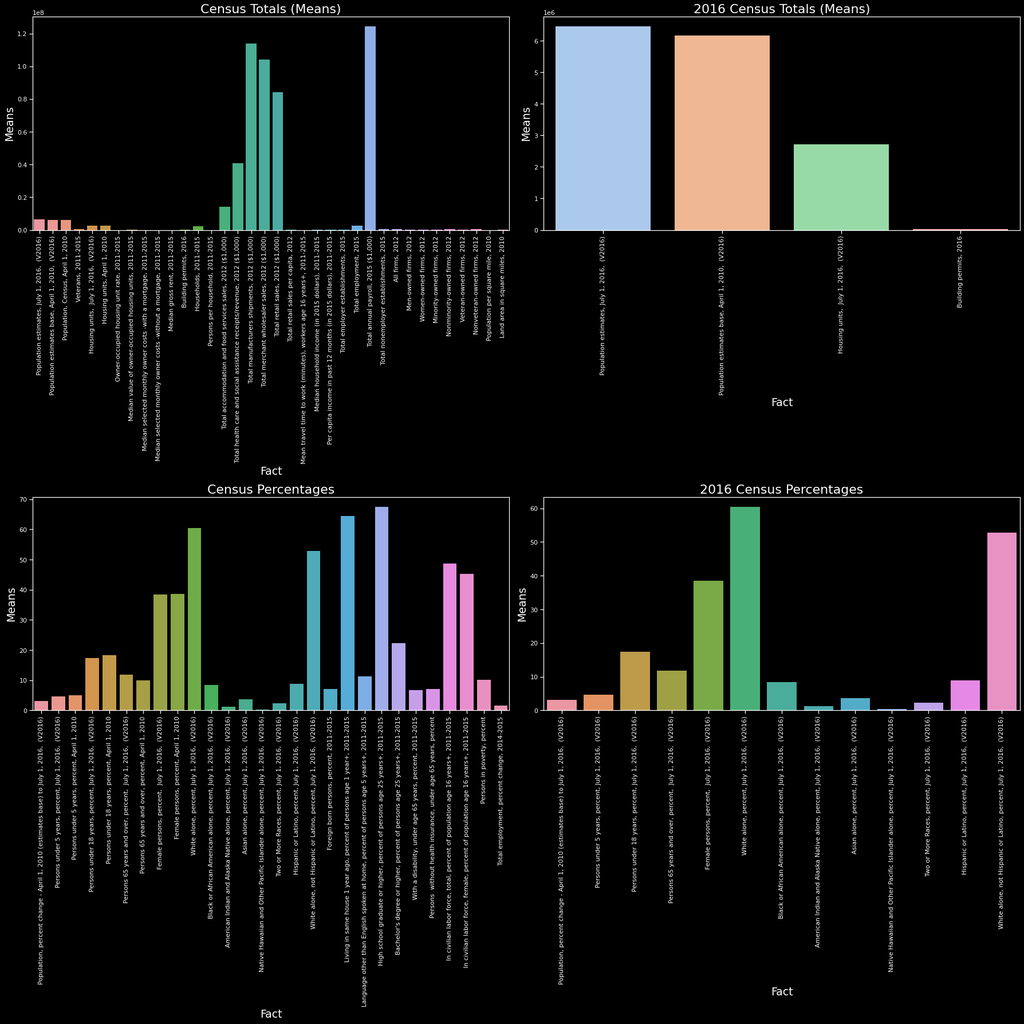

```python
# Customizing my plots
plt.rcParams['figure.figsize'] = (25, 25)
plt.style.use('dark_background')
sns.set_context('notebook', rc={'axes.titlesize':22, 'axes.labelsize':19})
sns.set_palette('pastel')

# Creating bar plots for census_tot, census_perc, census_2016_tot and census_2016_perc
plt.subplot(221)
sns.barplot(x = 'Fact', y = 'Means', data = census_tot)
plt.title('Census Totals (Means)')
plt.tick_params(axis = 'x', rotation = 90)

plt.subplot(222)
sns.barplot(x = 'Fact', y = 'Means', data = census_2016_tot)
plt.title('2016 Census Totals (Means)')
plt.tick_params(axis = 'x', rotation = 90)

plt.subplot(223)
sns.barplot(x = 'Fact', y = 'Means', data = census_perc)
plt.title('Census Percentages')
plt.tick_params(axis = 'x', rotation = 90)

plt.subplot(224)
sns.barplot(x = 'Fact', y = 'Means', data = census_2016_perc)
plt.title('2016 Census Percentages')
plt.tick_params(axis = 'x', rotation = 90)

# Show the plots
plt.tight_layout()
plt.show()
```

```python
# They are beautiful, but it's a little too much information.
# Creating dataframes of the few top values from each dataframe.
census_perc_largest = census_perc.nlargest(3, 'Means')
census_tot_largest = census_tot.nlargest(3, 'Means')
census_2016_perc_largest = census_2016_perc.nlargest(3, 'Means')
census_2016_tot_largest = census_2016_tot.nlargest(3, 'Means')

# Cleaning census_perc_largest dataframe.
census_perc_largest = census_perc_largest.drop('Means', axis = 1)
census_perc_largest.set_index('Fact', inplace=True)
census_perc_largest_t = census_perc_largest.T.reset_index()
census_perc_largest_t = census_perc_largest_t.rename(columns={'index':'State'})
census_perc_largest_t = census_perc_largest_t.set_index('State')
for i in census_perc_largest_t.columns[1:]:
    census_perc_largest_t[i] = pd.to_numeric(census_perc_largest_t[i], errors = 'coerce')

# Cleaning census_tot_largest dataframe.
census_tot_largest = census_tot_largest.drop('Means', axis = 1)
census_tot_largest.set_index('Fact', inplace=True)
census_tot_largest_t = census_tot_largest.T.reset_index()
census_tot_largest_t = census_tot_largest_t.rename(columns={'index':'State'})
census_tot_largest_t = census_tot_largest_t.set_index('State')
for i in census_tot_largest_t.columns[1:]:
    census_tot_largest_t[i] = pd.to_numeric(census_tot_largest_t[i], errors = 'coerce')

# Cleaning census_2016_perc_largest dataframe.
census_2016_perc_largest = census_2016_perc_largest.drop('Means', axis = 1)
census_2016_perc_largest.set_index('Fact', inplace=True)
census_2016_perc_largest_t = census_2016_perc_largest.T.reset_index()
census_2016_perc_largest_t = census_2016_perc_largest_t.rename(columns={'index':'State'})
census_2016_perc_largest_t = census_2016_perc_largest_t.set_index('State')
for i in census_2016_perc_largest_t.columns[1:]:
    census_2016_perc_largest_t[i] = pd.to_numeric(census_2016_perc_largest_t[i], errors = 'coerce')

# Cleaning census_2016_tot_largest dataframe.
census_2016_tot_largest = census_2016_tot_largest.drop('Means', axis = 1)
census_2016_tot_largest.set_index('Fact', inplace=True)
census_2016_tot_largest_t = census_2016_tot_largest.T.reset_index()
census_2016_tot_largest_t = census_2016_tot_largest_t.rename(columns={'index':'State'})
census_2016_tot_largest_t = census_2016_tot_largest_t.set_index('State')
for i in census_2016_tot_largest_t.columns[1:]:
    census_2016_tot_largest_t[i] = pd.to_numeric(census_2016_tot_largest_t[i], errors = 'coerce')
```

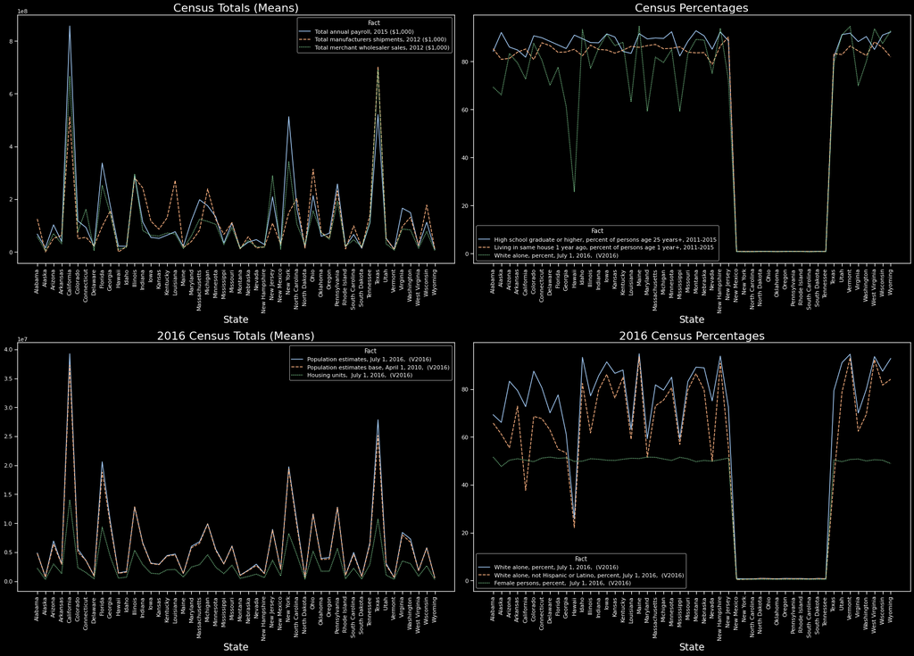

```python
# Plotting these dataframes
plt.rcParams['figure.figsize'] = (25, 18)

plt.subplot(221)
sns.lineplot(data = census_tot_largest_t)
plt.tick_params(axis = 'x', rotation = 90)
plt.title('Census Totals (Means)')

plt.subplot(222)
sns.lineplot(data = census_perc_largest_t)
plt.tick_params(axis = 'x', rotation = 90)
plt.title('Census Percentages')

plt.subplot(223)
sns.lineplot(data = census_2016_tot_largest_t)
plt.tick_params(axis = 'x', rotation = 90)
plt.title('2016 Census Totals (Means)')

plt.subplot(224)
sns.lineplot(data = census_2016_perc_largest_t)
plt.tick_params(axis = 'x', rotation = 90)
plt.title('2016 Census Percentages')

plt.tight_layout()
plt.show()
```

The dataframes containing percentages appear to have a problem with a block of data. I need to check it.

```python
census_perc_largest_t
```

| Fact State | High school graduate or higher, percent of persons age 25 years+, 2011-2015 | Living in same house 1 year ago, percent of persons age 1 year+, 2011-2015 | White alone, percent, July 1, 2016, (V2016) |
| --- | --- | --- | --- |
| Alabama | 84.300 | 85.300 | 69.300 |
| Alaska | 92.100 | 80.900 | 66.100 |
| Arizona | 86.000 | 81.300 | 83.300 |
| Arkansas | 84.800 | 83.900 | 79.400 |
| California | 81.800 | 85.200 | 72.700 |
| Colorado | 90.700 | 80.800 | 87.500 |
| Connecticut | 89.900 | 87.800 | 80.600 |
| Delaware | 88.400 | 86.600 | 70.100 |
| Florida | 86.900 | 83.800 | 77.600 |
| Georgia | 85.400 | 84.000 | 61.200 |
| Hawaii | 91.000 | 85.100 | 25.800 |
| Idaho | 89.500 | 82.400 | 93.300 |
| Illinois | 87.900 | 86.800 | 77.200 |
| Indiana | 87.800 | 85.000 | 85.600 |
| Iowa | 91.500 | 84.800 | 91.400 |
| Kansas | 90.200 | 83.500 | 86.600 |
| Kentucky | 84.200 | 84.700 | 88.000 |
| Louisiana | 83.400 | 86.300 | 63.200 |
| Maine | 91.600 | 85.900 | 94.800 |
| Maryland | 89.400 | 86.600 | 59.300 |
| Massachusetts | 89.800 | 87.100 | 81.800 |
| Michigan | 89.600 | 85.300 | 79.600 |
| Minnesota | 92.400 | 85.500 | 85.000 |
| Mississippi | 82.300 | 86.100 | 59.300 |
| Missouri | 88.400 | 83.900 | 83.200 |
| Montana | 92.800 | 83.600 | 89.200 |
| Nebraska | 90.700 | 83.700 | 88.900 |
| Nevada | 85.100 | 78.800 | 75.100 |
| New Hampshire | 92.300 | 86.500 | 93.800 |
| New Jersey | 88.600 | 90.200 | 72.400 |
| New Mexico | 0.842 | 0.857 | 0.826 |
| New York | 0.856 | 0.891 | 0.699 |
| North Carolina | 0.858 | 0.847 | 0.710 |
| North Dakota | 0.917 | 0.822 | 0.879 |
| Ohio | 0.891 | 0.853 | 0.825 |
| Oklahoma | 0.869 | 0.826 | 0.746 |
| Oregon | 0.898 | 0.819 | 0.874 |
| Pennsylvania | 0.892 | 0.880 | 0.824 |
| Rhode Island | 0.862 | 0.866 | 0.844 |
| South Carolina | 0.856 | 0.847 | 0.685 |
| South Dakota | 0.909 | 0.834 | 0.852 |
| Tennessee | 0.855 | 0.847 | 0.787 |
| Texas | 81.900 | 83.300 | 79.400 |
| Utah | 91.200 | 82.900 | 91.100 |
| Vermont | 91.800 | 86.500 | 94.600 |
| Virginia | 88.300 | 84.400 | 70.000 |
| Washington | 90.400 | 82.500 | 80.000 |
| West Virginia | 85.000 | 88.200 | 93.600 |
| Wisconsin | 91.000 | 85.800 | 87.500 |
| Wyoming | 92.300 | 81.900 | 92.800 |

```python
# Multiplying those values by 100 using iloc.
census_2016_perc_largest_t.iloc[30:42, 0:] = census_2016_perc_largest_t.iloc[30:42, 0:]* 100
# Check
census_2016_perc_largest_t
```

| Fact State | White alone, percent, July 1, 2016, (V2016) | White alone, not Hispanic or Latino, percent, July 1, 2016, (V2016) | Female persons, percent, July 1, 2016, (V2016) |
| --- | --- | --- | --- |
| Alabama | 69.3 | 65.8 | 51.6 |
| Alaska | 66.1 | 61.2 | 47.7 |
| Arizona | 83.3 | 55.5 | 50.3 |
| Arkansas | 79.4 | 72.9 | 50.9 |
| California | 72.7 | 37.7 | 50.3 |
| Colorado | 87.5 | 68.6 | 49.7 |
| Connecticut | 80.6 | 67.7 | 51.2 |
| Delaware | 70.1 | 62.9 | 51.6 |
| Florida | 77.6 | 54.9 | 51.1 |
| Georgia | 61.2 | 53.4 | 51.3 |
| Hawaii | 25.8 | 22.1 | 49.8 |
| Idaho | 93.3 | 82.4 | 49.9 |
| Illinois | 77.2 | 61.7 | 50.9 |
| Indiana | 85.6 | 79.6 | 50.7 |
| Iowa | 91.4 | 86.2 | 50.3 |
| Kansas | 86.6 | 76.3 | 50.2 |
| Kentucky | 88.0 | 85.0 | 50.7 |
| Louisiana | 63.2 | 59.0 | 51.1 |
| Maine | 94.8 | 93.5 | 51.0 |
| Maryland | 59.3 | 51.5 | 51.6 |
| Massachusetts | 81.8 | 73.0 | 51.5 |
| Michigan | 79.6 | 75.4 | 50.8 |
| Minnesota | 85.0 | 80.6 | 50.2 |
| Mississippi | 59.3 | 56.9 | 51.5 |
| Missouri | 83.2 | 79.7 | 50.9 |
| Montana | 89.2 | 86.5 | 49.7 |
| Nebraska | 88.9 | 79.6 | 50.2 |
| Nevada | 75.1 | 49.9 | 49.9 |
| New Hampshire | 93.8 | 90.8 | 50.5 |
| New Jersey | 72.4 | 55.8 | 51.2 |
| New Mexico | 82.6 | 38.1 | 50.5 |
| New York | 69.9 | 55.8 | 51.4 |
| North Carolina | 71.0 | 63.5 | 51.4 |
| North Dakota | 87.9 | 85.0 | 48.7 |
| Ohio | 82.5 | 79.5 | 51.0 |
| Oklahoma | 74.6 | 66.2 | 50.5 |
| Oregon | 87.4 | 76.4 | 50.5 |
| Pennsylvania | 82.4 | 77.0 | 51.0 |
| Rhode Island | 84.4 | 73.3 | 51.4 |
| South Carolina | 68.5 | 63.9 | 51.5 |
| South Dakota | 85.2 | 82.5 | 49.6 |
| Tennessee | 78.7 | 74.2 | 51.2 |
| Texas | 79.4 | 42.6 | 50.4 |
| Utah | 91.1 | 78.8 | 49.7 |
| Vermont | 94.6 | 93.1 | 50.6 |
| Virginia | 70.0 | 62.4 | 50.8 |
| Washington | 80.0 | 69.5 | 50.0 |
| West Virginia | 93.6 | 92.3 | 50.5 |
| Wisconsin | 87.5 | 81.7 | 50.3 |
| Wyoming | 92.8 | 84.1 | 48.9 |

```python
census_perc_largest_t.iloc[30:42, 0:] = census_perc_largest_t.iloc[30:42, 0:]* 100
# Check
census_perc_largest_t
```

| Fact State | High school graduate or higher, percent of persons age 25 years+, 2011-2015 | Living in same house 1 year ago, percent of persons age 1 year+, 2011-2015 | White alone, percent, July 1, 2016, (V2016) |
| --- | --- | --- | --- |
| Alabama | 84.3 | 85.3 | 69.3 |
| Alaska | 92.1 | 80.9 | 66.1 |
| Arizona | 86.0 | 81.3 | 83.3 |
| Arkansas | 84.8 | 83.9 | 79.4 |
| California | 81.8 | 85.2 | 72.7 |
| Colorado | 90.7 | 80.8 | 87.5 |
| Connecticut | 89.9 | 87.8 | 80.6 |
| Delaware | 88.4 | 86.6 | 70.1 |
| Florida | 86.9 | 83.8 | 77.6 |
| Georgia | 85.4 | 84.0 | 61.2 |
| Hawaii | 91.0 | 85.1 | 25.8 |
| Idaho | 89.5 | 82.4 | 93.3 |
| Illinois | 87.9 | 86.8 | 77.2 |
| Indiana | 87.8 | 85.0 | 85.6 |
| Iowa | 91.5 | 84.8 | 91.4 |
| Kansas | 90.2 | 83.5 | 86.6 |
| Kentucky | 84.2 | 84.7 | 88.0 |
| Louisiana | 83.4 | 86.3 | 63.2 |
| Maine | 91.6 | 85.9 | 94.8 |
| Maryland | 89.4 | 86.6 | 59.3 |
| Massachusetts | 89.8 | 87.1 | 81.8 |
| Michigan | 89.6 | 85.3 | 79.6 |
| Minnesota | 92.4 | 85.5 | 85.0 |
| Mississippi | 82.3 | 86.1 | 59.3 |
| Missouri | 88.4 | 83.9 | 83.2 |
| Montana | 92.8 | 83.6 | 89.2 |
| Nebraska | 90.7 | 83.7 | 88.9 |
| Nevada | 85.1 | 78.8 | 75.1 |
| New Hampshire | 92.3 | 86.5 | 93.8 |
| New Jersey | 88.6 | 90.2 | 72.4 |
| New Mexico | 84.2 | 85.7 | 82.6 |
| New York | 85.6 | 89.1 | 69.9 |
| North Carolina | 85.8 | 84.7 | 71.0 |
| North Dakota | 91.7 | 82.2 | 87.9 |
| Ohio | 89.1 | 85.3 | 82.5 |
| Oklahoma | 86.9 | 82.6 | 74.6 |
| Oregon | 89.8 | 81.9 | 87.4 |
| Pennsylvania | 89.2 | 88.0 | 82.4 |
| Rhode Island | 86.2 | 86.6 | 84.4 |
| South Carolina | 85.6 | 84.7 | 68.5 |
| South Dakota | 90.9 | 83.4 | 85.2 |
| Tennessee | 85.5 | 84.7 | 78.7 |
| Texas | 81.9 | 83.3 | 79.4 |
| Utah | 91.2 | 82.9 | 91.1 |
| Vermont | 91.8 | 86.5 | 94.6 |
| Virginia | 88.3 | 84.4 | 70.0 |
| Washington | 90.4 | 82.5 | 80.0 |
| West Virginia | 85.0 | 88.2 | 93.6 |
| Wisconsin | 91.0 | 85.8 | 87.5 |
| Wyoming | 92.3 | 81.9 | 92.8 |

Success

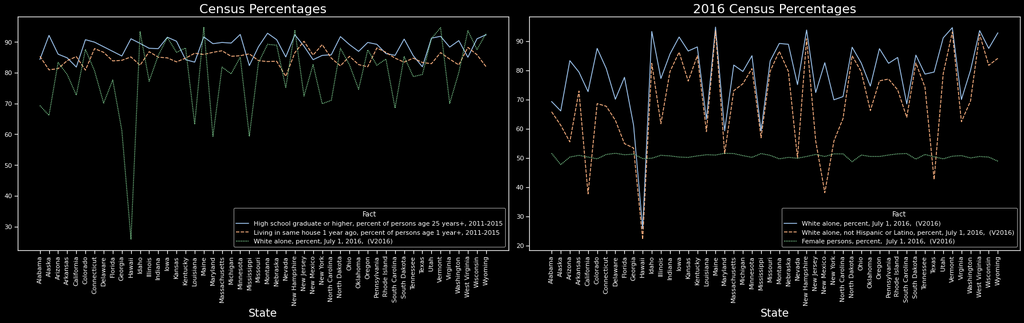

```python
# Plotting these dataframes again.
plt.rcParams['figure.figsize'] = (25, 8)

plt.subplot(121)
sns.lineplot(data = census_perc_largest_t)
plt.tick_params(axis = 'x', rotation = 90)
plt.title('Census Percentages')

plt.subplot(122)
sns.lineplot(data = census_2016_perc_largest_t)
plt.tick_params(axis = 'x', rotation = 90)
plt.title('2016 Census Percentages')

plt.tight_layout()
plt.show()
```

Beautiful

```python
# GUN_DF

# Creating a new dataframe with limited information that will be of use for this exploration.
gun_tidy = gun_df1.drop(gun_df1.columns.difference(['state', 'totals', 'year']), axis=1)
# Creating 2016 dataframe from gun_tidy
gun_2016 = gun_tidy[gun_tidy['year'] == 2016]
# Check
gun_2016.head()
```

|  | state | totals | year |
| --- | --- | --- | --- |
| 495 | Alabama | 62014.0 | 2016 |
| 496 | Alaska | 8786.0 | 2016 |
| 497 | Arizona | 44887.0 | 2016 |
| 498 | Arkansas | 29926.0 | 2016 |
| 499 | California | 298161.0 | 2016 |

```python
gun_2016.info()
```

```
<class 'pandas.core.frame.DataFrame'>
Int64Index: 600 entries, 495 to 1154
Data columns (total 3 columns):
 #   Column  Non-Null Count  Dtype
---  ------  --------------  -----
 0   state   600 non-null    object
 1   totals  600 non-null    float64
 2   year    600 non-null    int32
dtypes: float64(1), int32(1), object(1)
memory usage: 16.4+ KB
```

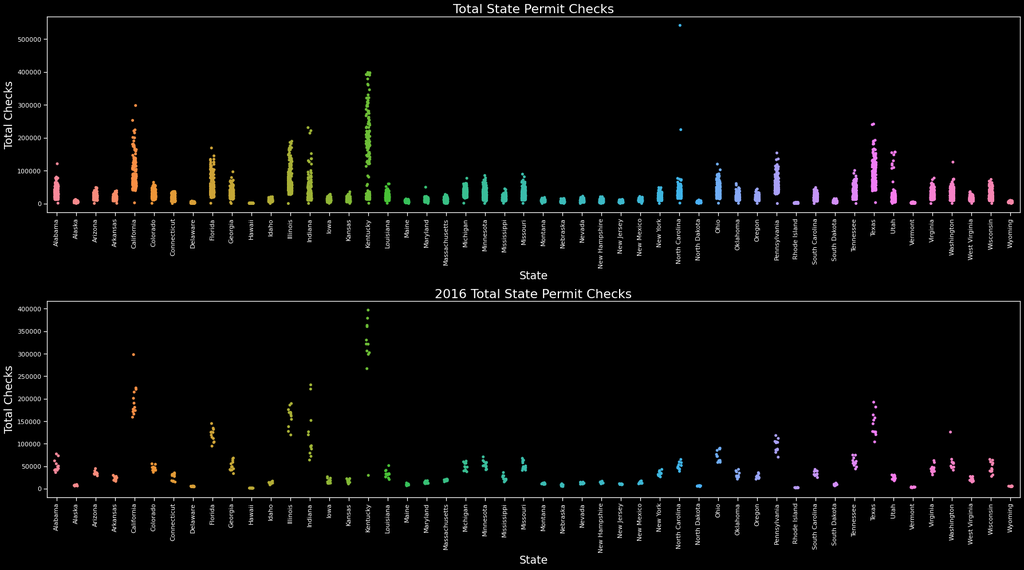

```python
# Plotting the totals of all years and only 2016. Using Stripplot to visually see outliers.
plt.rcParams['figure.figsize'] = (25, 14)

plt.subplot(211)
sns.stripplot(x = gun_tidy['state'], y = gun_tidy['totals'], data = gun_tidy)
plt.title('Total State Permit Checks')
plt.tick_params(axis = 'x', rotation = 90)
plt.ylabel('Total Checks')
plt.xlabel('State')

plt.subplot(212)
sns.stripplot(x = gun_2016['state'], y = gun_2016['totals'], data = gun_2016)
plt.title('2016 Total State Permit Checks')
plt.tick_params(axis = 'x', rotation = 90)
plt.ylabel('Total Checks')
plt.xlabel('State')

plt.tight_layout()
plt.show()
```

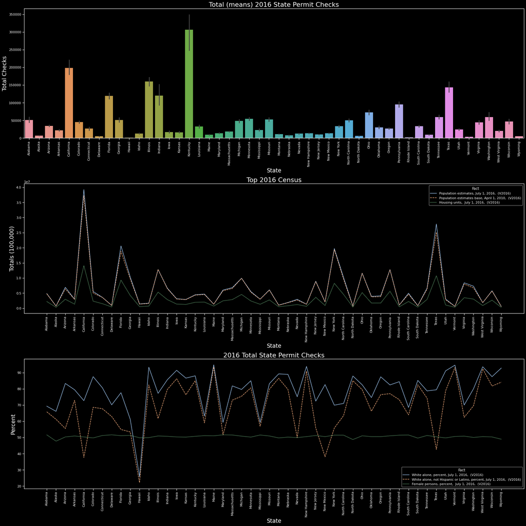

```python
plt.rcParams['figure.figsize'] = (25, 25)

plt.subplot(311)
sns.barplot(x = gun_tidy['state'], y = gun_2016['totals'], data = gun_tidy)
plt.title('Total (means) 2016 State Permit Checks')
plt.tick_params(axis = 'x', rotation = 90)
plt.ylabel('Total Checks')
plt.xlabel('State')

plt.subplot(312)
sns.lineplot(data = census_2016_tot_largest_t)
plt.title('Top 2016 Census')
plt.tick_params(axis = 'x', rotation = 90)
plt.ylabel('Totals (100,000)')
plt.xlabel('State')

plt.subplot(313)
sns.lineplot(data = census_2016_perc_largest_t)
plt.title('2016 Total State Permit Checks')
plt.tick_params(axis = 'x', rotation = 90)
plt.ylabel('Percent')
plt.xlabel('State')

plt.tight_layout()
plt.show()
```

Here I can see that even though Kentucky has the most background checks, there is no relation to 2016 census data like there is with California and Texas.

#### Question 1 Answer:

State populations appear to follow the same trends as state background checks for guns and explosives.

### Research Question 2: What type of gun has the most background checks performed?

```python
# Checking gun data columns
gun_df1.head()
```

|  | state | permit | permit_recheck | handgun | long_gun | other | multiple | admin | prepawn_handgun | prepawn_long_gun | ... | rentals_long_gun | private_sale_handgun | private_sale_long_gun | private_sale_other | return_to_seller_handgun | return_to_seller_long_gun | return_to_seller_other | totals | months | year |
| --- | --- | --- | --- | --- | --- | --- | --- | --- | --- | --- | --- | --- | --- | --- | --- | --- | --- | --- | --- | --- | --- |
| 0 | Alabama | 16717.0 | NaN | 5734.0 | 6320.0 | 221.0 | 317.0 | NaN | 15.0 | 21.0 | ... | NaN | 9.0 | 16.0 | 3.0 | NaN | NaN | 3.0 | 32019.0 | 9 | 2017 |
| 1 | Alaska | 209.0 | 2.0 | 2320.0 | 2930.0 | 219.0 | 160.0 | NaN | 5.0 | 2.0 | ... | NaN | 17.0 | 24.0 | 1.0 | NaN | NaN | NaN | 6303.0 | 9 | 2017 |
| 2 | Arizona | 5069.0 | 382.0 | 11063.0 | 7946.0 | 920.0 | 631.0 | NaN | 13.0 | 6.0 | ... | NaN | 38.0 | 12.0 | 2.0 | NaN | NaN | NaN | 28394.0 | 9 | 2017 |
| 3 | Arkansas | 2935.0 | 632.0 | 4347.0 | 6063.0 | 165.0 | 366.0 | 51.0 | 12.0 | 13.0 | ... | NaN | 13.0 | 23.0 | NaN | NaN | 2.0 | 1.0 | 17747.0 | 9 | 2017 |
| 4 | California | 57839.0 | NaN | 37165.0 | 24581.0 | 2984.0 | NaN | NaN | NaN | NaN | ... | NaN | NaN | NaN | NaN | NaN | NaN | NaN | 123506.0 | 9 | 2017 |

5 rows × 28 columns

```python
# Dropping last 3 columns and state columns to prep for a transpose
gun_df2 = gun_df1.iloc[:, :25]
gun_df2 = gun_df2.drop('state', axis=1)
# Check
gun_df2.head()
```

|  | permit | permit_recheck | handgun | long_gun | other | multiple | admin | prepawn_handgun | prepawn_long_gun | prepawn_other | ... | returned_long_gun | returned_other | rentals_handgun | rentals_long_gun | private_sale_handgun | private_sale_long_gun | private_sale_other | return_to_seller_handgun | return_to_seller_long_gun | return_to_seller_other |
| --- | --- | --- | --- | --- | --- | --- | --- | --- | --- | --- | --- | --- | --- | --- | --- | --- | --- | --- | --- | --- | --- |
| 0 | 16717.0 | NaN | 5734.0 | 6320.0 | 221.0 | 317.0 | NaN | 15.0 | 21.0 | 2.0 | ... | NaN | NaN | NaN | NaN | 9.0 | 16.0 | 3.0 | NaN | NaN | 3.0 |
| 1 | 209.0 | 2.0 | 2320.0 | 2930.0 | 219.0 | 160.0 | NaN | 5.0 | 2.0 | NaN | ... | 30.0 | NaN | NaN | NaN | 17.0 | 24.0 | 1.0 | NaN | NaN | NaN |
| 2 | 5069.0 | 382.0 | 11063.0 | 7946.0 | 920.0 | 631.0 | NaN | 13.0 | 6.0 | NaN | ... | 5.0 | NaN | NaN | NaN | 38.0 | 12.0 | 2.0 | NaN | NaN | NaN |
| 3 | 2935.0 | 632.0 | 4347.0 | 6063.0 | 165.0 | 366.0 | 51.0 | 12.0 | 13.0 | NaN | ... | NaN | NaN | NaN | NaN | 13.0 | 23.0 | NaN | NaN | 2.0 | 1.0 |
| 4 | 57839.0 | NaN | 37165.0 | 24581.0 | 2984.0 | NaN | NaN | NaN | NaN | NaN | ... | NaN | NaN | NaN | NaN | NaN | NaN | NaN | NaN | NaN | NaN |

5 rows × 24 columns

```python
# Transpose
gun_df2 = gun_df2.T
# Check
gun_df2.head()
```

|  | 0 | 1 | 2 | 3 | 4 | 5 | 6 | 7 | 9 | 10 | ... | 12474 | 12475 | 12476 | 12477 | 12478 | 12480 | 12481 | 12482 | 12483 | 12484 |
| --- | --- | --- | --- | --- | --- | --- | --- | --- | --- | --- | --- | --- | --- | --- | --- | --- | --- | --- | --- | --- | --- |
| permit | 16717.0 | 209.0 | 5069.0 | 2935.0 | 57839.0 | 4356.0 | 4343.0 | 275.0 | 10784.0 | 12074.0 | ... | NaN | NaN | NaN | NaN | NaN | NaN | 1.0 | 3.0 | NaN | 8.0 |
| permit_recheck | NaN | 2.0 | 382.0 | 632.0 | NaN | NaN | 673.0 | NaN | NaN | NaN | ... | NaN | NaN | NaN | NaN | NaN | NaN | NaN | NaN | NaN | NaN |
| handgun | 5734.0 | 2320.0 | 11063.0 | 4347.0 | 37165.0 | 15751.0 | 4834.0 | 1414.0 | 39199.0 | 10933.0 | ... | 8.0 | 19.0 | 1384.0 | 98.0 | 23.0 | 14.0 | 65.0 | 149.0 | 25.0 | 45.0 |
| long_gun | 6320.0 | 2930.0 | 7946.0 | 6063.0 | 24581.0 | 13448.0 | 1993.0 | 1538.0 | 17949.0 | 7982.0 | ... | 66.0 | 85.0 | 1349.0 | 169.0 | 35.0 | 2.0 | 286.0 | 251.0 | 214.0 | 49.0 |
| other | 221.0 | 219.0 | 920.0 | 165.0 | 2984.0 | 1007.0 | 274.0 | 66.0 | 2319.0 | 315.0 | ... | NaN | NaN | NaN | NaN | NaN | NaN | NaN | NaN | NaN | NaN |

5 rows × 11350 columns

```python
gun_df2 = gun_df2.reset_index()
gun_df2 = gun_df2.rename(columns={'index': 'Type'})
# Check
gun_df2.head()
```

|  | Type | 0 | 1 | 2 | 3 | 4 | 5 | 6 | 7 | 9 | ... | 12474 | 12475 | 12476 | 12477 | 12478 | 12480 | 12481 | 12482 | 12483 | 12484 |
| --- | --- | --- | --- | --- | --- | --- | --- | --- | --- | --- | --- | --- | --- | --- | --- | --- | --- | --- | --- | --- | --- |
| 0 | permit | 16717.0 | 209.0 | 5069.0 | 2935.0 | 57839.0 | 4356.0 | 4343.0 | 275.0 | 10784.0 | ... | NaN | NaN | NaN | NaN | NaN | NaN | 1.0 | 3.0 | NaN | 8.0 |
| 1 | permit_recheck | NaN | 2.0 | 382.0 | 632.0 | NaN | NaN | 673.0 | NaN | NaN | ... | NaN | NaN | NaN | NaN | NaN | NaN | NaN | NaN | NaN | NaN |
| 2 | handgun | 5734.0 | 2320.0 | 11063.0 | 4347.0 | 37165.0 | 15751.0 | 4834.0 | 1414.0 | 39199.0 | ... | 8.0 | 19.0 | 1384.0 | 98.0 | 23.0 | 14.0 | 65.0 | 149.0 | 25.0 | 45.0 |
| 3 | long_gun | 6320.0 | 2930.0 | 7946.0 | 6063.0 | 24581.0 | 13448.0 | 1993.0 | 1538.0 | 17949.0 | ... | 66.0 | 85.0 | 1349.0 | 169.0 | 35.0 | 2.0 | 286.0 | 251.0 | 214.0 | 49.0 |
| 4 | other | 221.0 | 219.0 | 920.0 | 165.0 | 2984.0 | 1007.0 | 274.0 | 66.0 | 2319.0 | ... | NaN | NaN | NaN | NaN | NaN | NaN | NaN | NaN | NaN | NaN |

5 rows × 11351 columns

```python
# Creating a 'totals' column that is the sum of each background check type
totals = gun_df2.sum(axis=1)
gun_df2['totals'] = totals
# Check
gun_df2.head()
```

|  | Type | 0 | 1 | 2 | 3 | 4 | 5 | 6 | 7 | 9 | ... | 12475 | 12476 | 12477 | 12478 | 12480 | 12481 | 12482 | 12483 | 12484 | totals |
| --- | --- | --- | --- | --- | --- | --- | --- | --- | --- | --- | --- | --- | --- | --- | --- | --- | --- | --- | --- | --- | --- |
| 0 | permit | 16717.0 | 209.0 | 5069.0 | 2935.0 | 57839.0 | 4356.0 | 4343.0 | 275.0 | 10784.0 | ... | NaN | NaN | NaN | NaN | NaN | 1.0 | 3.0 | NaN | 8.0 | 79908421.0 |
| 1 | permit_recheck | NaN | 2.0 | 382.0 | 632.0 | NaN | NaN | 673.0 | NaN | NaN | ... | NaN | NaN | NaN | NaN | NaN | NaN | NaN | NaN | NaN | 1282552.0 |
| 2 | handgun | 5734.0 | 2320.0 | 11063.0 | 4347.0 | 37165.0 | 15751.0 | 4834.0 | 1414.0 | 39199.0 | ... | 19.0 | 1384.0 | 98.0 | 23.0 | 14.0 | 65.0 | 149.0 | 25.0 | 45.0 | 73880599.0 |
| 3 | long_gun | 6320.0 | 2930.0 | 7946.0 | 6063.0 | 24581.0 | 13448.0 | 1993.0 | 1538.0 | 17949.0 | ... | 85.0 | 1349.0 | 169.0 | 35.0 | 2.0 | 286.0 | 251.0 | 214.0 | 49.0 | 97331240.0 |
| 4 | other | 221.0 | 219.0 | 920.0 | 165.0 | 2984.0 | 1007.0 | 274.0 | 66.0 | 2319.0 | ... | NaN | NaN | NaN | NaN | NaN | NaN | NaN | NaN | NaN | 1980262.0 |

5 rows × 11352 columns

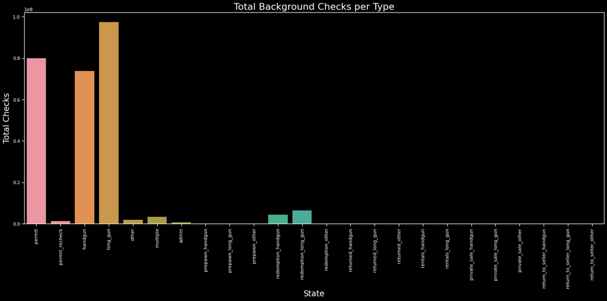

```python
# Creating bar plot to visually see differences
plt.rcParams['figure.figsize'] = (20, 10)

sns.barplot(x = gun_df2['Type'], y = gun_df2['totals'])
plt.title('Total Background Checks per Type')
plt.tick_params(axis = 'x', rotation = 90)
plt.ylabel('Total Checks')
plt.xlabel('State')

plt.tight_layout()
plt.show()
```

#### Question 2 Answer:

Long guns have the highest amount of background checks.

### Research Question 3: What US State performs the most background checks on the gun type answer (long guns) from question 2?

```python
# Checking gun_df1 columns
gun_df1.head()
```

|  | state | permit | permit_recheck | handgun | long_gun | other | multiple | admin | prepawn_handgun | prepawn_long_gun | ... | rentals_long_gun | private_sale_handgun | private_sale_long_gun | private_sale_other | return_to_seller_handgun | return_to_seller_long_gun | return_to_seller_other | totals | months | year |
| --- | --- | --- | --- | --- | --- | --- | --- | --- | --- | --- | --- | --- | --- | --- | --- | --- | --- | --- | --- | --- | --- |
| 0 | Alabama | 16717.0 | NaN | 5734.0 | 6320.0 | 221.0 | 317.0 | NaN | 15.0 | 21.0 | ... | NaN | 9.0 | 16.0 | 3.0 | NaN | NaN | 3.0 | 32019.0 | 9 | 2017 |
| 1 | Alaska | 209.0 | 2.0 | 2320.0 | 2930.0 | 219.0 | 160.0 | NaN | 5.0 | 2.0 | ... | NaN | 17.0 | 24.0 | 1.0 | NaN | NaN | NaN | 6303.0 | 9 | 2017 |
| 2 | Arizona | 5069.0 | 382.0 | 11063.0 | 7946.0 | 920.0 | 631.0 | NaN | 13.0 | 6.0 | ... | NaN | 38.0 | 12.0 | 2.0 | NaN | NaN | NaN | 28394.0 | 9 | 2017 |
| 3 | Arkansas | 2935.0 | 632.0 | 4347.0 | 6063.0 | 165.0 | 366.0 | 51.0 | 12.0 | 13.0 | ... | NaN | 13.0 | 23.0 | NaN | NaN | 2.0 | 1.0 | 17747.0 | 9 | 2017 |
| 4 | California | 57839.0 | NaN | 37165.0 | 24581.0 | 2984.0 | NaN | NaN | NaN | NaN | ... | NaN | NaN | NaN | NaN | NaN | NaN | NaN | 123506.0 | 9 | 2017 |

5 rows × 28 columns

```python
# Dropping all but 'state' and 'long_gun' columns
gun_df3 = gun_df1.drop(gun_df1.columns.difference(['state', 'long_gun']), axis=1)
# Check
gun_df3.head()
```

|  | state | long_gun |
| --- | --- | --- |
| 0 | Alabama | 6320.0 |
| 1 | Alaska | 2930.0 |
| 2 | Arizona | 7946.0 |
| 3 | Arkansas | 6063.0 |
| 4 | California | 24581.0 |

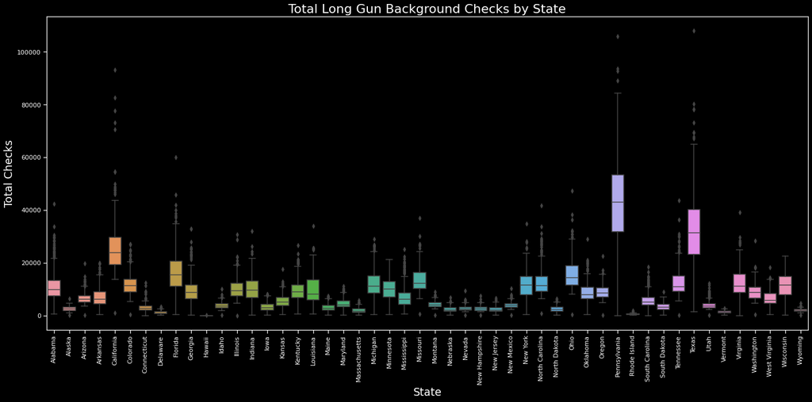

```python
# Creating a box plot to visually compare differences
plt.rcParams['figure.figsize'] = (20, 10)

sns.boxplot(x = gun_df3['state'], y = gun_df3['long_gun'])
plt.title('Total Long Gun Background Checks by State')
plt.tick_params(axis = 'x', rotation = 90)
plt.ylabel('Total Checks')
plt.xlabel('State')

plt.tight_layout()
plt.show()
```

#### Question 3 Answer:

Pennsylvania has the highest amount of long gun backgound checks compared to all other US States.

## Conclusions

After getting a more in-depth look at the 2016 Census data and the FBI gun data, I was able to compare 2016 data from both datasets by using the US States as a key identifier. From this, I found that population size generally follows the same trends as background checks for guns and explosives. Kentucky had the highest amount of background checks which did not directly correlate to the state population. Kentucky performs monthly background checks on every concealed carry permit holder. However, California, Texas, and Florida were among many other states whose 2016 population trends closely followed 2016 FBI background checks for guns and explosives. By exploring the FBI gun data, I found that the highest amount of background checks are performed on long guns. Then from this discovery, I found that Pennsylvania is the state that performs the most background checks for long guns.

It is important to note that there are some limitations with the data and each background check does not represent the number of firearms sold. Based on varying state laws and purchase scenarios, a one-to-one correlation cannot be made between a firearm background check and a firearm sale. Investigative reporter, Jacob Ryan (2015), found that Kentucky runs a NICS check on each concealed carry license holder, once a month, which makes their numbers stand out in comparison to all other US States. According to the 2016 NICS Operations Report, only 31 US States fully worked with the NICS for all firearm background checks, and 7 US States contact the NICS only for handgun and long gun backgrounds checks. The rest of the background checks are done at a state level. Even with these limitations, the FBI’s NICS numbers are still widely accepted as the model for total gun sales in a given time period.

## References

Kentucky’s Background Checks For Gun Owners Stand Out By Jacob Ryan https://wfpl.org/kentucky-background-checks-stand-out/

2016 NICS Operations Report https://www.fbi.gov/file-repository/2016-nics-operations-report-final-5-3-2017.pdf/view

FBI Gun Dataset https://github.com/BuzzFeedNews/nics-firearm-background-checks/blob/master/README.md

Census Data https://data.census.gov/cedsci/